# Weighted Subgroup Analysis

Monte Carlo Simulation Evidence – RDD Path

Author

Alvaro Carril

Published

May 27, 2026

```r
library(ggplot2)
library(dplyr)
library(tidyr)
library(scales)

# Results directory (relative to this file)
RES <- "simulation_results"

# Shared aesthetics
PAL <- c(Naive = "#c0392b", WSGA = "#2980b9", `Full saturation` = "#27ae60")
LTY <- c(Naive = "dashed",  WSGA = "solid",   `Full saturation` = "dotted")

theme_sim <- function(base = 13) {
  theme_minimal(base_size = base) +
  theme(
    panel.grid.minor  = element_blank(),
    panel.grid.major  = element_line(colour = "grey92"),
    strip.background  = element_rect(fill = "#f0f0f0", colour = NA),
    strip.text        = element_text(face = "bold", size = rel(0.95)),
    legend.position   = "bottom",
    legend.title      = element_blank(),
    plot.title        = element_text(face = "bold"),
    plot.subtitle     = element_text(colour = "grey40", size = rel(0.9)),
    axis.title        = element_text(size = rel(0.9)),
    plot.caption      = element_text(colour = "grey50", size = rel(0.78),
                                     hjust = 0, margin = margin(t = 8))
  )
}
```

## 1 Overview

This document reports four Monte Carlo scenarios that validate the core statistical properties of `wsga` for **sharp regression discontinuity (RD)** designs. All scenarios use the same underlying data-generating process (DGP) and are run with $R = 1{,}000$ replications per cell. The script that produced these results lives at `simulation/run_simulations.R`.

## 2 Data-generating process

The DGP is a sharp RD with one observable moderator $M$ that is imbalanced across subgroups:

$$y_i = \underbrace{\bigl(2 + \beta_M M_i\bigr) Z_i (1 - G_i)}_{\text{G=0 treatment response}}
+ \underbrace{\bigl(2 + \beta_G + \beta_M M_i\bigr) Z_i G_i}_{\text{G=1 treatment response}}
+ 0.3\, x_i (1-G_i) + 0.5\, x_i G_i + \varepsilon_i$$

| Term | Distribution | Role |
| --- | --- | --- |
| $x_i$ | $U(-1,1)$ | Running variable |
| $Z_i = \mathbf{1}[x_i \ge 0]$ | Sharp | Treatment assignment |
| $G_i$ | $\text{Bern}(0.5)$ | Binary subgroup |
| $M_i = \delta G_i + \varepsilon_M$ | $\varepsilon_M \sim N(0,1)$ | Moderator (imbalanced by $\delta$) |
| $\varepsilon_i$ | $N(0, 0.25)$ | Idiosyncratic noise |

**True per-group RD effects**: $b_{G=0} = 2$, $b_{G=1} = 2 + \beta_G$. **True differential**: $\Delta = \beta_G$, set per scenario: $\Delta = 2$ for the bias and unobservable scenarios (S1, S4), $\Delta = 0$ for the size scenario (S2), $\Delta = 0.5$ for the power scenario (S3).

The key feature is that $M$ amplifies the *treatment response* (it multiplies $Z$, not just $y$). This means the within-group RD estimate for $G=1$ picks up $\beta_M \cdot E[M \mid G=1] = \beta_M \delta$, creating a bias of $\beta_M \delta$ in the naive cross-subgroup comparison. IPW (WSGA) removes this bias by reweighting $M$ to the same distribution across groups.

Two estimators are compared throughout:

- **Naive** – `wsga_rdd(y ~ 1 | G, noipsw = TRUE)`: no adjustment for $M$.
- **WSGA** – `wsga_rdd(y ~ 1 | G, balance = ~ M, noipsw = FALSE)`: $M$ enters the propensity score only; outcome regression remains lean.

Both use analytical inference (no bootstrap) for speed, except Scenario 1b which uses the pairs bootstrap to assess coverage.

## 3 Scenario 1 – Bias removal

**Design**: sweep $\delta \in \{0, 0.5, 1, 2\}$ and $\beta_M \in \{0, 0.3, 0.5\}$ at $n \in \{300, 600, 1500\}$. Report **bias** (mean estimate $- \Delta$) and **RMSE**.

**Prediction**: naive bias $\approx \beta_M \delta$; WSGA bias $\approx 0$.

```r
s1 <- read.csv(file.path(RES, "s1_bias_rmse.csv")) |>
  mutate(
    beta_M_lab = factor(paste0("beta[M] == ", beta_M),
                        levels = paste0("beta[M] == ", sort(unique(beta_M)))),
    n_lab = factor(paste0("n = ", n), levels = paste0("n = ", sort(unique(n))))
  )
```

### Bias

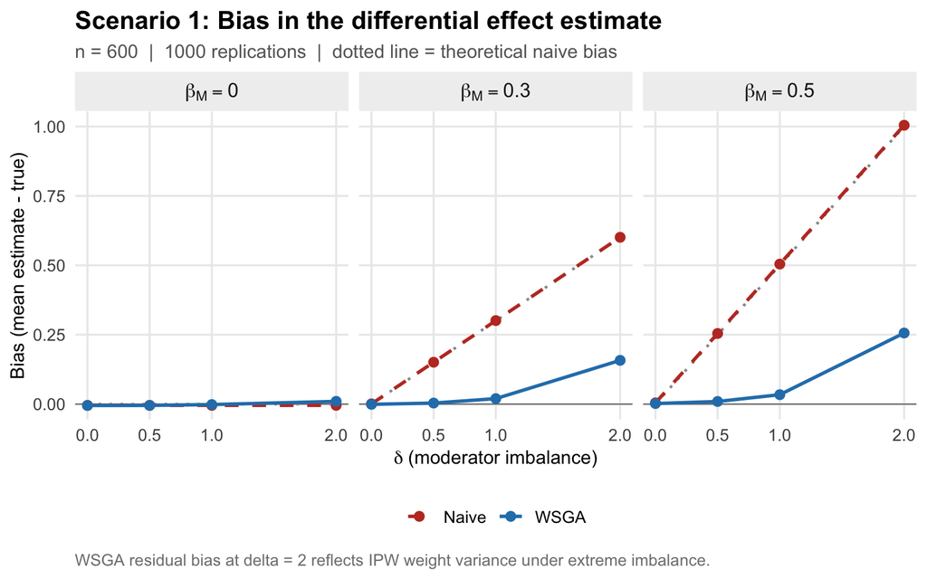

```r
s1_long <- s1 |>
  select(n, delta, beta_M, beta_M_lab, n_lab, bias_naive, bias_wsga) |>
  pivot_longer(c(bias_naive, bias_wsga),
               names_to = "method", values_to = "bias") |>
  mutate(method = recode(method, bias_naive = "Naive", bias_wsga = "WSGA"))

# Theoretical naive bias line
theory <- s1 |>
  select(n, delta, beta_M, beta_M_lab, n_lab) |>
  distinct() |>
  mutate(theory = beta_M * delta)

ggplot(s1_long |> filter(n == 600),
       aes(x = delta, y = bias, colour = method, linetype = method)) +
  geom_hline(yintercept = 0, colour = "grey50", linewidth = 0.4) +
  geom_line(data = theory |> filter(n == 600),
            aes(x = delta, y = theory, group = beta_M_lab),
            colour = "grey60", linetype = "dotted", linewidth = 0.8,
            inherit.aes = FALSE) +
  geom_line(linewidth = 1) +
  geom_point(size = 2.5) +
  facet_wrap(~ beta_M_lab, labeller = label_parsed, nrow = 1) +
  scale_colour_manual(values = PAL) +
  scale_linetype_manual(values = LTY) +
  scale_x_continuous(breaks = c(0, 0.5, 1, 2)) +
  labs(
    title    = "Scenario 1: Bias in the differential effect estimate",
    subtitle = "n = 600  |  1000 replications  |  dotted line = theoretical naive bias",
    x        = expression(delta ~ "(moderator imbalance)"),
    y        = "Bias (mean estimate - true)",
    caption  = "WSGA residual bias at delta = 2 reflects IPW weight variance under extreme imbalance."
  ) +
  theme_sim()
```

### RMSE

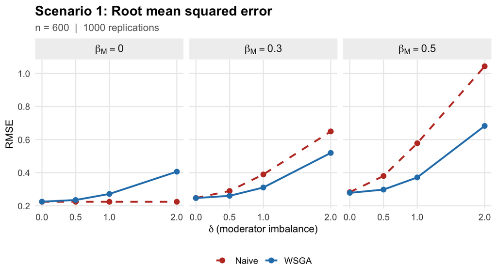

```r
s1_rmse <- s1 |>
  select(n, delta, beta_M, beta_M_lab, n_lab, rmse_naive, rmse_wsga) |>
  pivot_longer(c(rmse_naive, rmse_wsga),
               names_to = "method", values_to = "rmse") |>
  mutate(method = recode(method, rmse_naive = "Naive", rmse_wsga = "WSGA"))

ggplot(s1_rmse |> filter(n == 600),
       aes(x = delta, y = rmse, colour = method, linetype = method)) +
  geom_line(linewidth = 1) +
  geom_point(size = 2.5) +
  facet_wrap(~ beta_M_lab, labeller = label_parsed, nrow = 1) +
  scale_colour_manual(values = PAL) +
  scale_linetype_manual(values = LTY) +
  scale_x_continuous(breaks = c(0, 0.5, 1, 2)) +
  labs(
    title    = "Scenario 1: Root mean squared error",
    subtitle = "n = 600  |  1000 replications",
    x        = expression(delta ~ "(moderator imbalance)"),
    y        = "RMSE"
  ) +
  theme_sim()
```

## 4 Scenario 1b – Bootstrap coverage

**Design**: 500 reps of WSGA with pairs bootstrap ($B = 100$) at $\delta \in \{0, 1\}$, $\beta_M = 0.3$, $n \in \{300, 600, 1500\}$. Target: 95% CI empirical coverage.

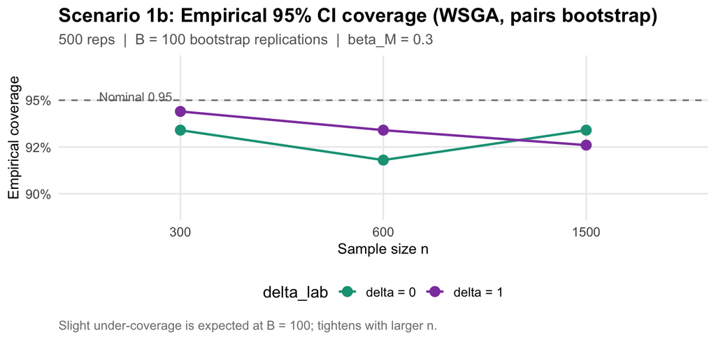

```r
s1b <- read.csv(file.path(RES, "s1_coverage.csv")) |>
  mutate(delta_lab = paste0("delta = ", delta))

ggplot(s1b, aes(x = factor(n), y = coverage, colour = delta_lab,
                group = delta_lab)) +
  geom_hline(yintercept = 0.95, colour = "grey50", linetype = "dashed",
             linewidth = 0.6) +
  geom_line(linewidth = 0.9) +
  geom_point(size = 3.5) +
  annotate("text", x = 0.6, y = 0.952, label = "Nominal 0.95",
           colour = "grey40", size = 3.5, hjust = 0) +
  scale_y_continuous(limits = c(0.89, 0.97), labels = percent_format(1)) +
  scale_colour_manual(values = c("#16a085", "#8e44ad")) +
  labs(
    title    = "Scenario 1b: Empirical 95% CI coverage (WSGA, pairs bootstrap)",
    subtitle = "500 reps  |  B = 100 bootstrap replications  |  beta_M = 0.3",
    x        = "Sample size n",
    y        = "Empirical coverage",
    caption  = "Slight under-coverage is expected at B = 100; tightens with larger n."
  ) +
  theme_sim() +
  theme(legend.title = element_text())
```

Coverage is 0.918-0.944 across all cells – modest under-coverage typical of bootstrap CIs at $B = 100$. Coverage is not sensitive to the imbalance level $\delta$, suggesting the bias is adequately removed before the bootstrap runs.

## 5 Scenario 2 – Size control

**Design**: true differential $\Delta = 0$ (null); sweep $\delta \in \{0, 0.5, 1, 2\}$ and $\beta_M \in \{0, 0.3\}$ at $n = 600$. Report the 5%-level rejection rate.

**Prediction**: naive over-rejects when $\delta > 0$ and $\beta_M > 0$; WSGA maintains nominal size.

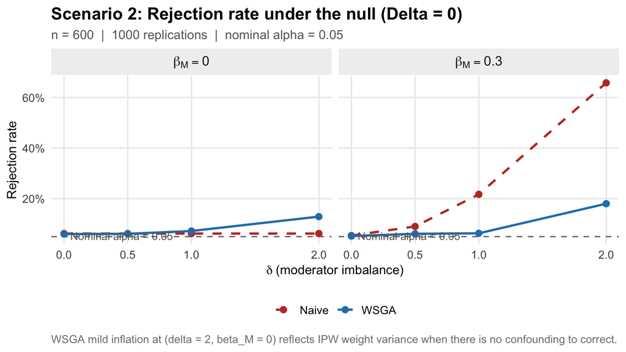

```r
s2 <- read.csv(file.path(RES, "s2_size.csv")) |>
  mutate(beta_M_lab = factor(paste0("beta[M] == ", beta_M),
                              levels = paste0("beta[M] == ", sort(unique(beta_M)))))

s2_long <- s2 |>
  pivot_longer(c(size_naive, size_wsga),
               names_to = "method", values_to = "size") |>
  mutate(method = recode(method, size_naive = "Naive", size_wsga = "WSGA"))

ggplot(s2_long |> filter(n == 600),
       aes(x = delta, y = size, colour = method, linetype = method)) +
  geom_hline(yintercept = 0.05, colour = "grey50", linetype = "dashed",
             linewidth = 0.6) +
  geom_line(linewidth = 1) +
  geom_point(size = 2.5) +
  annotate("text", x = 0.05, y = 0.053, label = "Nominal alpha = 0.05",
           colour = "grey40", size = 3.5, hjust = 0) +
  facet_wrap(~ beta_M_lab, labeller = label_parsed, nrow = 1) +
  scale_colour_manual(values = PAL) +
  scale_linetype_manual(values = LTY) +
  scale_x_continuous(breaks = c(0, 0.5, 1, 2)) +
  scale_y_continuous(labels = percent_format(1)) +
  labs(
    title    = "Scenario 2: Rejection rate under the null (Delta = 0)",
    subtitle = "n = 600  |  1000 replications  |  nominal alpha = 0.05",
    x        = expression(delta ~ "(moderator imbalance)"),
    y        = "Rejection rate",
    caption  = paste0(
      "WSGA mild inflation at (delta = 2, beta_M = 0) reflects IPW weight variance ",
      "when there is no confounding to correct."
    )
  ) +
  theme_sim()
```

## 6 Scenario 3 – Power as a function of K

**Design**: $K \in \{0, 1, 2, 4, 6, 8\}$ continuous moderators ($M_k \sim N(0.4\, G, 1)$) with no direct effect on $y$. True $\Delta = 0.5$. Three estimators:

| Estimator | Outcome formula | Propensity score |
| --- | --- | --- |
| Naive | `y ~ 1 \\| G` | None (noipsw) |
| WSGA | `y ~ 1 \\| G` | $M_1 + \ldots + M_K$ |
| Full saturation | `y ~ M1 + ... + MK \\| G` | None (noipsw) |

Full saturation adds $2K$ df to the outcome regression; WSGA adds $K$ logit parameters to the propensity score but keeps the outcome lean.

> **Note on the comparison.** The Calonico et al. “full saturation” approach cells on all $2^K$ moderator combinations, adding $2^K$ parameters – far more than the $2K$ in our linear-covariate proxy. With $K = 8$ and $n = 600$, $2^8 = 256$ cells average fewer than 2.5 observations each, making the approach infeasible. We show the linear-covariate proxy as the most optimistic comparator available in this framework.

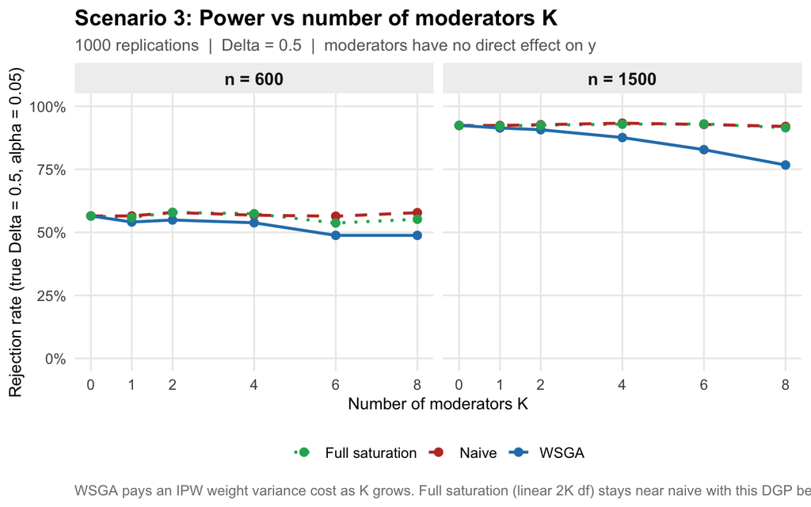

```r
s3 <- read.csv(file.path(RES, "s3_power_vs_K.csv")) |>
  mutate(n_lab = factor(paste0("n = ", n), levels = paste0("n = ", sort(unique(n)))))

s3_long <- s3 |>
  pivot_longer(c(power_naive, power_wsga, power_full),
               names_to = "method", values_to = "power") |>
  mutate(method = recode(method,
    power_naive = "Naive",
    power_wsga  = "WSGA",
    power_full  = "Full saturation"))

ggplot(s3_long, aes(x = K, y = power, colour = method, linetype = method)) +
  geom_line(linewidth = 1) +
  geom_point(size = 2.5) +
  facet_wrap(~ n_lab, nrow = 1) +
  scale_colour_manual(values = PAL) +
  scale_linetype_manual(values = LTY) +
  scale_x_continuous(breaks = c(0, 1, 2, 4, 6, 8)) +
  scale_y_continuous(labels = percent_format(1), limits = c(0, 1)) +
  labs(
    title    = "Scenario 3: Power vs number of moderators K",
    subtitle = "1000 replications  |  Delta = 0.5  |  moderators have no direct effect on y",
    x        = "Number of moderators K",
    y        = "Rejection rate (true Delta = 0.5, alpha = 0.05)",
    caption  = paste0(
      "WSGA pays an IPW weight variance cost as K grows. ",
      "Full saturation (linear 2K df) stays near naive with this DGP because ",
      "moderators add no residual variance reduction. ",
      "Cell-splitting (2^K parameters) would collapse far faster."
    )
  ) +
  theme_sim()
```

With no direct $y$-effect from the moderators, full saturation’s 2K df overhead is small relative to sample size, so its power barely moves. WSGA’s power declines more noticeably because the propensity score model with K continuous moderators creates IPW weight variance even when the weights are not needed to remove bias.